# Usando Regressão Linear para Explicar a votação de Deputados

Matheus Leal

11 de outubro de 2018

```r
library(here)
library(tidyverse)
```

## Introdução

##### Esta análise utilizará conceitos de regressão linear para tentar explicar as votações que os deputados receberam em 2006 e 2010. Esses dados foram extraídos do TSE, pré-processados e contemplam informações sobre aproximadamente 7.300 candidatos.

##### Primeiro, vamos importar os dados referentes às eleições. Antes de utilizar os dados, iremos realizar alguns ajustes, tais quais tratamento de NAs e alterar os tipos de algumas variáveis de factor para character.

```r
eleicoes_data <- read_csv(here('lab-03/eleicoes_2006_e_2010.csv'),
    col_types = cols(
      ano = col_integer(),
      sequencial_candidato = col_character(),
      quantidade_doacoes = col_integer(),
      quantidade_doadores = col_integer(),
      total_receita = col_double(),
      media_receita = col_double(),
      recursos_de_outros_candidatos.comites = col_double(),
      recursos_de_pessoas_fisicas = col_double(),
      recursos_de_pessoas_juridicas = col_double(),
      recursos_proprios = col_double(),
      `recursos_de_partido_politico` = col_double(),
      quantidade_despesas = col_integer(),
      quantidade_fornecedores = col_integer(),
      total_despesa = col_double(),
      media_despesa = col_double(),
      votos = col_integer(),
      .default = col_character()))

dados <- na.omit(eleicoes_data) %>%   mutate(nome = as.character(nome),
         uf = as.character(uf),
         partido = as.character(partido),
         cargo = as.character(cargo),
         sexo = as.character(sexo),
         grau = as.character(grau),
         estado_civil = as.character(estado_civil),
         ocupacao = as.character(ocupacao)
         )
```

## Perguntas

##### Antes de qualquer coisa, abaixo um visão geral dos dados, quais colunas o data frame contém e o que significam.

```r
dados %>%  glimpse()
```

```
## Observations: 7,476
## Variables: 24
## $ ano                                   <int> 2006, 2006, 2006, 2006, ...
## $ sequencial_candidato                  <chr> "10001", "10002", "10002...
## $ nome                                  <chr> "JOSÉ LUIZ NOGUEIRA DE S...
## $ uf                                    <chr> "AP", "RO", "AP", "MS", ...
## $ partido                               <chr> "PT", "PT", "PT", "PRONA...
## $ quantidade_doacoes                    <int> 6, 13, 17, 6, 48, 6, 14,...
## $ quantidade_doadores                   <int> 6, 13, 16, 6, 48, 6, 7, ...
## $ total_receita                         <dbl> 16600.00, 22826.00, 1581...
## $ media_receita                         <dbl> 2766.67, 1755.85, 9301.2...
## $ recursos_de_outros_candidatos.comites <dbl> 0.00, 6625.00, 2250.00, ...
## $ recursos_de_pessoas_fisicas           <dbl> 9000.00, 15000.00, 34150...
## $ recursos_de_pessoas_juridicas         <dbl> 6300.00, 1000.00, 62220....
## $ recursos_proprios                     <dbl> 1300.00, 201.00, 59500.0...
## $ recursos_de_partido_politico          <dbl> 0, 0, 0, 0, 0, 0, 0, 0, ...
## $ quantidade_despesas                   <int> 14, 24, 123, 8, 133, 9, ...
## $ quantidade_fornecedores               <int> 14, 23, 108, 8, 120, 9, ...
## $ total_despesa                         <dbl> 16583.60, 20325.99, 1460...
## $ media_despesa                         <dbl> 1184.54, 846.92, 1187.09...
## $ cargo                                 <chr> "DEPUTADO FEDERAL", "DEP...
## $ sexo                                  <chr> "MASCULINO", "FEMININO",...
## $ grau                                  <chr> "ENSINO MÉDIO COMPLETO",...
## $ estado_civil                          <chr> "CASADO(A)", "SOLTEIRO(A...
## $ ocupacao                              <chr> "VEREADOR", "SERVIDOR PÚ...
## $ votos                                 <int> 8579, 2757, 17428, 1193,...
```

### Descrição dos Dados

#### O significado das variáveis:

##### “sequencial_candidato” :(character) id do candidato

##### “nome”: (character)

##### “uf”: (character)

##### “partido”: (character)

##### “quantidade_doacoes”: (integer)

##### “quantidade_doadores”: (integer) número de doadores diferentes

##### “total_receita”: (double) soma em R$ das doações

##### “media_receita”: (double) média das doações

##### “recursos_de_outros_candidatos/comites”: (double) quantia em R$ das doações provenientes de outros candidatos ou comite partidário

##### “recursos_de_pessoas_fisicas”: (double) quantia em R$ das doações provenientes de outros CPFs

##### “recursos_de_pessoas_juridicas”: (double) quantia em R$ das doações provenientes de outros CNPJ

##### “recursos_proprios”: (double) quantia em R$ das doações provenientes do próprio candidato

##### “recursos_de_partido_politico”: (double) quantia em R$ das doações provenientes do partido político do candidato

##### “votos”: (integer) variável alvo. Se refere ao número de votos na campanha de 2006 e 2010

##### “quantidade_despesas”: (integer)

##### “quantidade_fornecedores”: (integer) número de fornecedores/despesas diferentes

##### “total_despesa”: (double) soma em R$ das despesas de campanha

##### “media_despesa”: (double) média das despesas de campanha

##### “cargo”: (character)

##### “Sexo”: (character)

##### “grau”: (character) grau de instrução do candidato

##### “estado_civil”: (character)

##### “ocupacao”: (character) ocupação do candidato

### 1. Um modelo de regressão múltipla com todas as variáveis é plausível para explicar a variação em y (número de votos) em 2006? Mesma pergunta para 2010.

##### Antes, iremos retirar algumas varíveis dos nosso modelo que não se mostram tão interessantes para nossa análise, como nome do candidato, seu cargo (tendo em vista que todos são iguais), ano da eleição, ocupação e o sequencial dos candidatos.

```r
eleicoes_2006 <- dados %>% filter(ano == "2006") %>% select(-nome, -sequencial_candidato, -cargo, -ano, -ocupacao, -uf)

modelo <- lm(data = eleicoes_2006, votos ~ ., na.action = na.omit)

modelo %>%   summary()
```

```
##
## Call:
## lm(formula = votos ~ ., data = eleicoes_2006, na.action = na.omit)
##
## Residuals:
##     Min      1Q  Median      3Q     Max
## -224446   -8628   -3278    1851  629036
##
## Coefficients: (1 not defined because of singularities)
##                                         Estimate Std. Error t value
## (Intercept)                           -6.150e+03  5.044e+03  -1.219
## partidoPC do B                         9.356e+03  5.922e+03   1.580
## partidoPCB                            -3.463e+03  1.867e+04  -0.185
## partidoPCO                            -6.261e+02  1.355e+04  -0.046
## partidoPDT                             2.364e+03  4.598e+03   0.514
## partidoPFL                             9.975e+03  4.848e+03   2.057
## partidoPHS                            -1.325e+02  5.358e+03  -0.025
## partidoPL                              4.955e+03  4.891e+03   1.013
## partidoPMDB                            9.036e+03  4.641e+03   1.947
## partidoPMN                             2.436e+03  5.201e+03   0.468
## partidoPP                              1.716e+04  4.938e+03   3.476
## partidoPPS                            -3.615e+02  4.728e+03  -0.076
## partidoPRB                             5.247e+03  9.406e+03   0.558
## partidoPRONA                           4.983e+03  5.523e+03   0.902
## partidoPRP                             2.285e+02  6.420e+03   0.036
## partidoPRTB                           -9.314e+02  6.456e+03  -0.144
## partidoPSB                             6.335e+03  4.648e+03   1.363
## partidoPSC                             3.160e+03  5.082e+03   0.622
## partidoPSDB                            5.993e+03  4.688e+03   1.279
## partidoPSDC                           -1.614e+03  5.774e+03  -0.279
## partidoPSL                            -1.073e+03  6.332e+03  -0.169
## partidoPSOL                            1.868e+03  5.084e+03   0.367
## partidoPSTU                            6.471e+02  8.746e+03   0.074
## partidoPT                              6.317e+03  4.611e+03   1.370
## partidoPT do B                        -9.028e+01  6.556e+03  -0.014
## partidoPTB                             4.565e+03  4.879e+03   0.936
## partidoPTC                             7.668e+03  5.939e+03   1.291
## partidoPTN                            -1.087e+03  7.195e+03  -0.151
## partidoPV                              4.593e+02  4.670e+03   0.098
## quantidade_doacoes                    -8.326e+01  1.240e+02  -0.672
```

[output cut: 68 more lines]

```
## grauENSINO MÉDIO COMPLETO             0.435046
## grauENSINO MÉDIO INCOMPLETO           0.862475
## grauLÊ E ESCREVE                      0.417703
## grauSUPERIOR COMPLETO                 0.051479 .
## grauSUPERIOR INCOMPLETO               0.272853
## estado_civilDIVORCIADO(A)             0.218815
## estado_civilSEPARADO(A) JUDICIALMENTE 0.841982
## estado_civilSOLTEIRO(A)               0.591153
## estado_civilVIÚVO(A)                  0.598507
## ---
## Signif. codes:  0 '***' 0.001 '**' 0.01 '*' 0.05 '.' 0.1 ' ' 1
##
## Residual standard error: 31480 on 3384 degrees of freedom
## Multiple R-squared:  0.5279, Adjusted R-squared:  0.5207
## F-statistic: 74.19 on 51 and 3384 DF,  p-value: < 2.2e-16
```

```r
eleicoes_2010 <- dados %>% filter(ano == "2010") %>% select(-nome, -sequencial_candidato, -cargo, -ano, -ocupacao, -uf)

modelo2 <- lm(data = eleicoes_2010, votos ~ ., na.action = na.omit)

modelo2 %>%   summary()
```

```
##
## Call:
## lm(formula = votos ~ ., data = eleicoes_2010, na.action = na.omit)
##
## Residuals:
##     Min      1Q  Median      3Q     Max
## -204223  -10005   -4030    1498 1239333
##
## Coefficients: (1 not defined because of singularities)
##                                         Estimate Std. Error t value
## (Intercept)                            9.591e+03  4.075e+03   2.354
## partidoPC do B                        -2.932e+03  4.670e+03  -0.628
## partidoPCB                            -1.517e+04  1.149e+04  -1.320
## partidoPCO                            -9.036e+03  2.147e+04  -0.421
## partidoPDT                            -4.244e+03  3.797e+03  -1.118
## partidoPHS                            -1.017e+04  4.340e+03  -2.343
## partidoPMDB                            9.169e+02  3.592e+03   0.255
## partidoPMN                            -1.059e+04  4.111e+03  -2.577
## partidoPP                              1.617e+03  4.000e+03   0.404
## partidoPPS                            -4.061e+03  4.439e+03  -0.915
## partidoPR                              1.492e+04  4.287e+03   3.480
## partidoPRB                            -2.160e+03  4.611e+03  -0.469
## partidoPRP                            -1.065e+04  5.392e+03  -1.974
## partidoPRTB                           -1.200e+04  4.943e+03  -2.427
## partidoPSB                             2.628e+03  3.729e+03   0.705
## partidoPSC                            -4.201e+03  4.138e+03  -1.015
## partidoPSDB                           -3.290e+03  3.761e+03  -0.875
## partidoPSDC                           -1.181e+04  6.030e+03  -1.959
## partidoPSL                            -1.253e+04  4.548e+03  -2.755
## partidoPSOL                           -8.456e+03  4.030e+03  -2.098
## partidoPSTU                           -1.106e+04  8.072e+03  -1.371
## partidoPT                              1.874e+03  3.620e+03   0.518
## partidoPT do B                        -8.233e+03  4.831e+03  -1.704
## partidoPTB                            -6.784e+03  3.728e+03  -1.820
## partidoPTC                            -1.123e+04  3.957e+03  -2.837
## partidoPTN                            -1.249e+04  5.464e+03  -2.285
## partidoPV                             -8.819e+03  3.648e+03  -2.418
## quantidade_doacoes                     5.181e+01  5.365e+01   0.966
## quantidade_doadores                   -3.828e+01  6.221e+01  -0.615
## total_receita                         -8.239e-03  9.430e-03  -0.874
```

[output cut: 64 more lines]

```
## grauENSINO MÉDIO COMPLETO             0.868228
## grauENSINO MÉDIO INCOMPLETO           0.779726
## grauLÊ E ESCREVE                      1.15e-10 ***
## grauSUPERIOR COMPLETO                 0.077361 .
## grauSUPERIOR INCOMPLETO               0.795451
## estado_civilDIVORCIADO(A)             0.130105
## estado_civilSEPARADO(A) JUDICIALMENTE 0.209023
## estado_civilSOLTEIRO(A)               0.031190 *
## estado_civilVIÚVO(A)                  0.179875
## ---
## Signif. codes:  0 '***' 0.001 '**' 0.01 '*' 0.05 '.' 0.1 ' ' 1
##
## Residual standard error: 36720 on 3990 degrees of freedom
## Multiple R-squared:  0.4578, Adjusted R-squared:  0.4511
## F-statistic: 68.74 on 49 and 3990 DF,  p-value: < 2.2e-16
```

##### Agora, vamos complementar nossa primeira análise com os graficos:

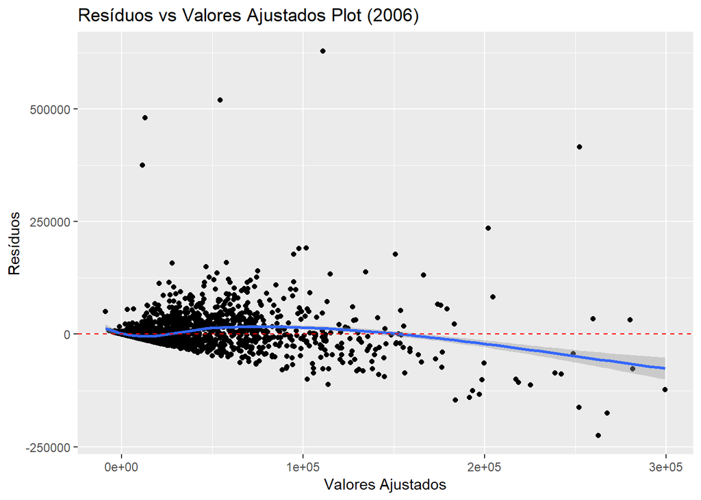

```r
modelo %>%
  ggplot(aes(.fitted, .resid)) +
  geom_point() +
  stat_smooth(method="loess") +
  geom_hline(col="red",
             yintercept = 0,
             linetype="dashed") +
  labs(y="Resíduos",
       x="Valores Ajustados",
       title="Resíduos vs Valores Ajustados Plot (2006)")
```

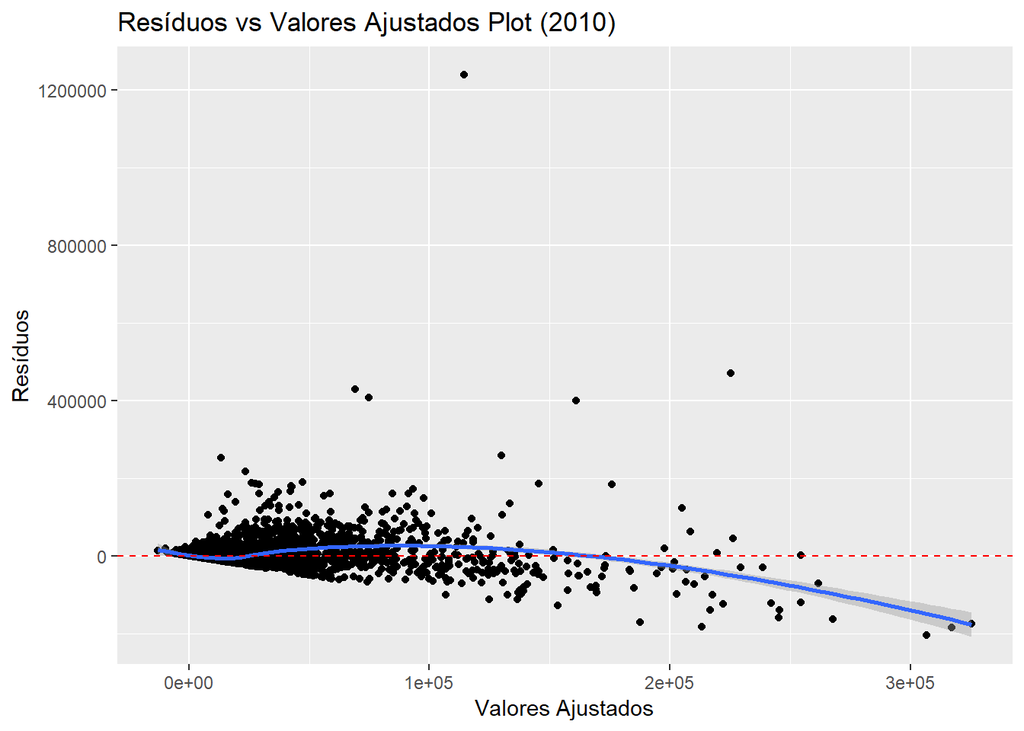

```r
modelo2 %>%
  ggplot(aes(.fitted, .resid)) +
  geom_point() +
  stat_smooth(method="loess") +
  geom_hline(col="red",
             yintercept = 0,
             linetype="dashed") +
  labs(y="Resíduos",
       x="Valores Ajustados",
       title="Resíduos vs Valores Ajustados Plot (2010)")
```

### 3. Todas as variáveis são úteis para os modelos de regressão? Há variáveis redudantes? Faça análises para 2006 e 2010 separadamente

##### Iremos tirar do nosso modelo todas as variáveis categoricas, para que possamos analisar a correlação entre as variáveis quantitativas.

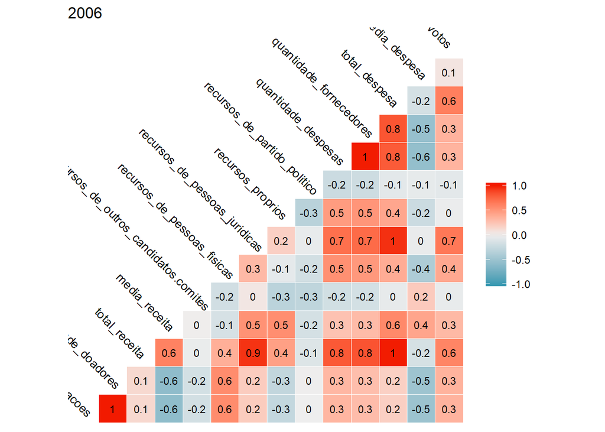

```r
library(GGally)
el2006 <- eleicoes_2006 %>% select(-partido, -estado_civil, -sexo, -grau)

corr = el2006[, 0:14] %>%  cor() %>%  round(2)

corr %>%  ggcorr(label_size = 3, label = TRUE, label_color = "black", hjust = 0.925, size = 3.5, angle = -45) + labs(title = "2006")
```

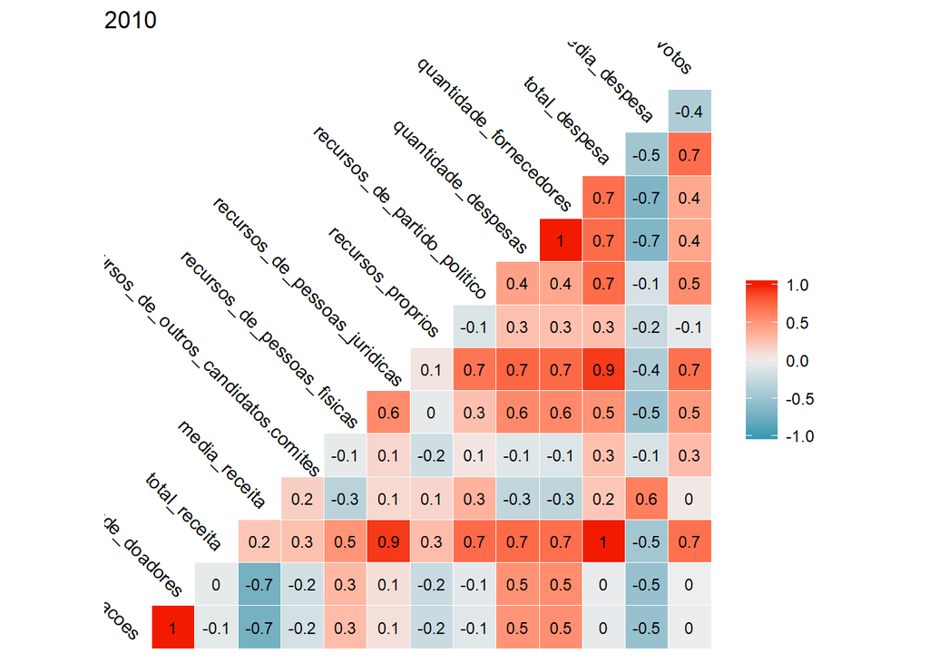

```r
el2010 <- eleicoes_2010 %>% select(-partido, -estado_civil, -sexo, -grau)

corr2 = el2010[, 0:14] %>%  cor() %>%  round(2)

corr2 %>%  ggcorr(label_size = 3, label = TRUE, label_color = "black", hjust = 0.925, size = 3.5, angle = -45) + labs(title = "2010")
```

### 4. No caso de haver variáveis pouco explicativas e/ou redudantes, construa um novo modelo sem essas variáveis e o compare ao modelo com todas as variáveis (e.g. em termos de R2 e RSE). Faça isso para 2006 e 2010 separadamente

```r
e2006 <- el2006  %>% select(-total_receita, -quantidade_fornecedores)

modelo_novo <- lm(data = e2006, votos ~ ., na.action = na.omit)

modelo_novo %>%   summary()
```

```
##
## Call:
## lm(formula = votos ~ ., data = e2006, na.action = na.omit)
##
## Residuals:
##     Min      1Q  Median      3Q     Max
## -230763   -7028   -4502    -748  640530
##
## Coefficients:
##                                         Estimate Std. Error t value
## (Intercept)                           3829.14681  703.83513   5.440
## quantidade_doacoes                     -78.87028  124.25789  -0.635
## quantidade_doadores                    349.48281  134.18267   2.605
## media_receita                            1.21277    0.10412  11.647
## recursos_de_outros_candidatos.comites   -0.06471    0.01921  -3.369
## recursos_de_pessoas_fisicas              0.05737    0.01753   3.272
## recursos_de_pessoas_juridicas           -0.03088    0.01153  -2.678
## recursos_proprios                       -0.09454    0.01308  -7.227
## recursos_de_partido_politico            -0.10572    0.02178  -4.853
## quantidade_despesas                    -26.62830    3.36242  -7.919
## total_despesa                            0.13646    0.01279  10.665
## media_despesa                            0.86363    0.41790   2.067
##                                       Pr(>|t|)
## (Intercept)                           5.69e-08 ***
## quantidade_doacoes                    0.525647
## quantidade_doadores                   0.009240 **
## media_receita                          < 2e-16 ***
## recursos_de_outros_candidatos.comites 0.000764 ***
## recursos_de_pessoas_fisicas           0.001079 **
## recursos_de_pessoas_juridicas         0.007446 **
## recursos_proprios                     6.07e-13 ***
## recursos_de_partido_politico          1.27e-06 ***
## quantidade_despesas                   3.20e-15 ***
## total_despesa                          < 2e-16 ***
## media_despesa                         0.038849 *
## ---
## Signif. codes:  0 '***' 0.001 '**' 0.01 '*' 0.05 '.' 0.1 ' ' 1
##
## Residual standard error: 31640 on 3424 degrees of freedom
## Multiple R-squared:  0.5173, Adjusted R-squared:  0.5158
## F-statistic: 333.6 on 11 and 3424 DF,  p-value: < 2.2e-16
```

##### Para 2006, mesmo removendo as variáveis categóricas e aquelas que possuiam uma alta correlação com as outras, nosso modelo perdeu pouco mais de 1% de acuracia, o que indica que as variáveis removidas eram pouco úteis para explicação dos dados.

```r
e2010 <- el2010  %>% select(-total_receita, -quantidade_despesas)

modelo_novo <- lm(data = e2010, votos ~ ., na.action = na.omit)

modelo_novo %>%   summary()
```

```
##
## Call:
## lm(formula = votos ~ ., data = e2010, na.action = na.omit)
##
## Residuals:
##     Min      1Q  Median      3Q     Max
## -222488   -8174   -7364   -3209 1303465
##
## Coefficients:
##                                         Estimate Std. Error t value
## (Intercept)                            8.313e+03  6.574e+02  12.645
## quantidade_doacoes                     4.464e+01  5.412e+01   0.825
## quantidade_doadores                   -2.953e+01  6.274e+01  -0.471
## media_receita                         -1.809e-01  5.411e-02  -3.343
## recursos_de_outros_candidatos.comites  2.775e-03  9.113e-03   0.305
## recursos_de_pessoas_fisicas            4.517e-02  1.196e-02   3.778
## recursos_de_pessoas_juridicas         -6.251e-03  8.094e-03  -0.772
## recursos_proprios                     -3.333e-02  8.555e-03  -3.896
## recursos_de_partido_politico          -2.996e-03  8.613e-03  -0.348
## quantidade_fornecedores               -1.490e+01  2.721e+00  -5.478
## total_despesa                          8.110e-02  8.904e-03   9.109
## media_despesa                          1.452e-01  9.004e-02   1.613
##                                       Pr(>|t|)
## (Intercept)                            < 2e-16 ***
## quantidade_doacoes                    0.409534
## quantidade_doadores                   0.637930
## media_receita                         0.000837 ***
## recursos_de_outros_candidatos.comites 0.760736
## recursos_de_pessoas_fisicas           0.000160 ***
## recursos_de_pessoas_juridicas         0.439965
## recursos_proprios                     9.95e-05 ***
## recursos_de_partido_politico          0.727991
## quantidade_fornecedores               4.55e-08 ***
## total_despesa                          < 2e-16 ***
## media_despesa                         0.106887
## ---
## Signif. codes:  0 '***' 0.001 '**' 0.01 '*' 0.05 '.' 0.1 ' ' 1
##
## Residual standard error: 37330 on 4028 degrees of freedom
## Multiple R-squared:  0.4341, Adjusted R-squared:  0.4326
## F-statistic: 280.9 on 11 and 4028 DF,  p-value: < 2.2e-16
```

```r
eleicoes <- dados  %>% select(-nome, -sequencial_candidato, -cargo, -ano, -ocupacao, -uf)

modelo_novo <- lm(data = eleicoes, votos ~ ., na.action = na.omit)

modelo_novo %>%   summary()
```

```
##
## Call:
## lm(formula = votos ~ ., data = eleicoes, na.action = na.omit)
##
## Residuals:
##     Min      1Q  Median      3Q     Max
## -325910  -11474   -4532    1880 1261518
##
## Coefficients: (1 not defined because of singularities)
##                                         Estimate Std. Error t value
## (Intercept)                            5.298e+02  3.546e+03   0.149
## partidoPAN                            -4.051e+03  5.562e+03  -0.728
## partidoPC do B                         6.227e+03  4.029e+03   1.545
## partidoPCB                            -8.095e+03  1.004e+04  -0.806
## partidoPCO                            -5.023e+03  1.234e+04  -0.407
## partidoPDT                             8.718e+02  3.270e+03   0.267
## partidoPFL                             2.058e+04  3.893e+03   5.285
## partidoPHS                            -4.315e+03  3.747e+03  -1.152
## partidoPL                              7.604e+03  4.027e+03   1.888
## partidoPMDB                            1.055e+04  3.201e+03   3.297
## partidoPMN                            -2.993e+03  3.611e+03  -0.829
## partidoPP                              1.186e+04  3.463e+03   3.425
## partidoPPS                             2.934e+02  3.472e+03   0.085
## partidoPR                              1.876e+04  4.184e+03   4.485
## partidoPRB                             3.305e+03  4.341e+03   0.762
## partidoPRONA                           2.197e+03  5.004e+03   0.439
## partidoPRP                            -4.307e+03  4.496e+03  -0.958
## partidoPRTB                           -5.897e+03  4.291e+03  -1.374
## partidoPSB                             7.579e+03  3.275e+03   2.314
## partidoPSC                             1.563e+03  3.580e+03   0.437
## partidoPSDB                            6.522e+03  3.265e+03   1.997
## partidoPSDC                           -5.275e+03  4.448e+03  -1.186
## partidoPSL                            -6.287e+03  4.058e+03  -1.550
## partidoPSOL                           -2.255e+03  3.544e+03  -0.636
## partidoPSTU                           -4.180e+03  6.317e+03  -0.662
## partidoPT                              9.809e+03  3.197e+03   3.068
## partidoPT do B                        -2.887e+03  4.252e+03  -0.679
## partidoPTB                             1.281e+03  3.354e+03   0.382
## partidoPTC                            -2.905e+03  3.656e+03  -0.795
## partidoPTN                            -6.275e+03  4.707e+03  -1.333
```

[output cut: 72 more lines]

```
## grauENSINO MÉDIO COMPLETO             0.359328
## grauENSINO MÉDIO INCOMPLETO           0.717577
## grauLÊ E ESCREVE                      6.87e-11 ***
## grauSUPERIOR COMPLETO                 0.000465 ***
## grauSUPERIOR INCOMPLETO               0.179589
## estado_civilDIVORCIADO(A)             0.048528 *
## estado_civilSEPARADO(A) JUDICIALMENTE 0.399172
## estado_civilSOLTEIRO(A)               0.003866 **
## estado_civilVIÚVO(A)                  0.141455
## ---
## Signif. codes:  0 '***' 0.001 '**' 0.01 '*' 0.05 '.' 0.1 ' ' 1
##
## Residual standard error: 35930 on 7422 degrees of freedom
## Multiple R-squared:  0.4373, Adjusted R-squared:  0.4333
## F-statistic: 108.8 on 53 and 7422 DF,  p-value: < 2.2e-16
```

##### Para mais informações acesse: http://www.tse.jus.br/